# *Lavorare con i Database in R: il pacchetto DBI*

[figure not shown]

# 1 Librerie

Installare le librerie

```r
# install.packages(c("DBI", "dbplyr", "dplyr", "dbplot", "ggplot2", "modeldb","tidypredict", "config"))
```

Caricare le librerie

```r
library(DBI)
```

# 2 Connessione ed esplorazione

## 2.1 Connessione

Per la connessione a quasi tutti i DB, in R si utilizza il comando `dbconnect()` del package `DBI`. Questo definisce una interfaccia fra R e il DBMS. La funzione ha due argomenti:

- *il driver*: nel nostro caso useremo SQLite.
- *nome e indirizzo del DB*: nel nostro caso useremo un DB locale, perciò è sufficiente specificare l’inidirizzo del DB su PC.

R comunica con i databases di tipo SQLite attraverso il pacchetto `RSQLite`.

Una volta stabilita la connessione, questa viene mantenuta fino al momento in cui non si disconnette il DB, attraverso il comando `dbDisconnect()`.

```r
con <- DBI::dbConnect(RSQLite::SQLite(), dbname = "data/mydatabase.db")
```

Questo comando non produce alcun output, ma la connessione diventa visibile nel pannello *Environment*. I dati non sono stati caricati, ma è stata creta una connessione ad essi.

Per esplorare alcuni dettagli della connessione possiamo:

1. Guardarli nel pannello *Environment*:

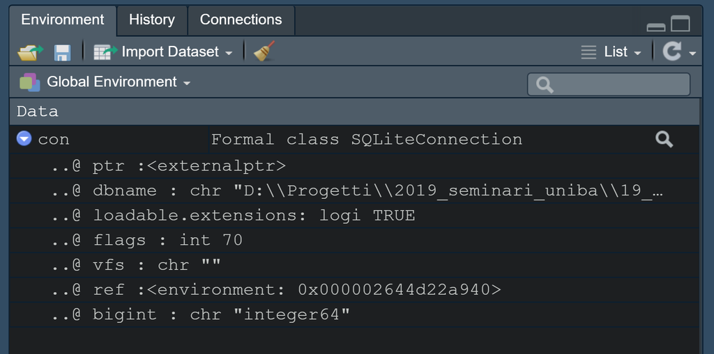

2. Digitare `[nome_connessione]`

```r
con
```

```
<SQLiteConnection>
  Path: D:\Progetti\2019_seminari_uniba\19_12_10_2_RdataBases_Dovidio\data\mydatabase.db
  Extensions: TRUE
```

3. richiamare una `summary` della connessione

```r
summary(con)
```

```
          Length            Class             Mode
               1 SQLiteConnection               S4
```

## 2.2 Lista delle tabelle

Per ottenere la lista delle tabelle contenute nel DB, si usa `dbListTables()`

```r
DBI::dbListTables(con)
```

```
[1] "COMPANY"    "DEPARTMENT" "ecom"       "trade"
```

## 2.3 Lista dei campi/colonne

Prima di eseguire operazioni su una tabella, esploriamone il contenuto, cioè i campi(colonne) utilizzando `dbListFields()`. Questo comando ha due imput:

1. il nome della connessione
2. il nome (fra apici) della tabella

```r
DBI::dbListFields(con, "ecom")
```

```
 [1] "id"          "referrer"    "device"      "bouncers"
 [5] "n_visit"     "n_pages"     "duration"    "country"
 [9] "purchase"    "order_items" "order_value"
```

# 3 Interrograzione del Database

## 3.1 Leggere l’intera tabella

Per leggere una intera tabella si utilizza `dbReadTable()`. Questo comando è sconsigliato in caso di tabelle di dimensioni molto grandi. Nel nostro caso, poichè le tabelle di esempio sono si piccole dimensioni, possiamo leggerle interamente. La funzione ha due argomenti:

Questo comando ha due input:

1. il nome della connessione
2. il nome (fra apici) della tabella

```r
DBI::dbReadTable(con, "COMPANY")
```

| ID | NAME | AGE | ADDRESS | SALARY |
| --- | --- | --- | --- | --- |
| 1 | Paul | 32 | California | 20000 |
| 2 | Allen | 25 | Texas | 15000 |
| 3 | Teddy | 23 | Norway | 20000 |
| 4 | Mark | 25 | Rich-Mond | 65000 |
| 5 | David | 27 | Texas | 85000 |
| 6 | Kim | 22 | South-Hall | 45000 |

## 3.2 Leggere alcune righe

In alcuni casi non serve l’intera tabella, ma solamente un certo numero di righe. In questo caso il comando `dbGetQuery()` permette di especificare uno statement SQL per l’estrazione dei dati, specificando il numero di righe ad leggere.

```r
DBI::dbGetQuery(con, "SELECT * FROM ecom LIMIT 10")
```

| id | referrer | device | bouncers | n_visit | n_pages | duration | country | purchase | order_items | order_value |
| --- | --- | --- | --- | --- | --- | --- | --- | --- | --- | --- |
| 1 | google | laptop | true | 10 | 1 | 693 | Czech Republic | false | 0 | 0 |
| 2 | yahoo | tablet | true | 9 | 1 | 459 | Yemen | false | 0 | 0 |
| 3 | direct | laptop | true | 0 | 1 | 996 | Brazil | false | 0 | 0 |
| 4 | bing | tablet | false | 3 | 18 | 468 | China | true | 6 | 434 |
| 5 | yahoo | mobile | true | 9 | 1 | 955 | Poland | false | 0 | 0 |
| 6 | yahoo | laptop | false | 5 | 5 | 135 | South Africa | false | 0 | 0 |
| 7 | yahoo | mobile | true | 10 | 1 | 75 | Bangladesh | false | 0 | 0 |
| 8 | direct | mobile | true | 10 | 1 | 908 | Indonesia | false | 0 | 0 |
| 9 | bing | mobile | false | 3 | 19 | 209 | Netherlands | false | 0 | 0 |
| 10 | google | mobile | true | 6 | 1 | 208 | Czech Republic | false | 0 | 0 |

Il comando `dbGetQuery()` permette di eseguire query di vario tipo, utilizzando direttamente codice SQL. Ne vedremo altri utilizzi in seguito.

## 3.3 Leggere i dati in batches

DBI consente anche di impostare una query e poi eseguirla a blocchi. Ciò è possibile usando i comandi `dbSendQuery()` e `dbFetch()`. Il primo invia la query al DB e resta in attesa di un comando *fetch* che vada a prendere l risultato di quella query un po alla volta.

### 3.3.1 Impostare la query

PEr impostare la query, utilizziamo `dbSendQuery()`. Queto comando non produce alcun output.

In seguito richiamo alcune righe dell’output con `dbFetch()`. Questo comando ha due imput:

- il nome della query,
- il numero di righe.

```r
query  <- DBI::dbSendQuery(con, 'SELECT * FROM ecom')
result <- DBI::dbFetch(query, n = 15)
result
```

| id | referrer | device | bouncers | n_visit | n_pages | duration | country | purchase | order_items | order_value |
| --- | --- | --- | --- | --- | --- | --- | --- | --- | --- | --- |
| 1 | google | laptop | true | 10 | 1 | 693 | Czech Republic | false | 0 | 0 |
| 2 | yahoo | tablet | true | 9 | 1 | 459 | Yemen | false | 0 | 0 |
| 3 | direct | laptop | true | 0 | 1 | 996 | Brazil | false | 0 | 0 |
| 4 | bing | tablet | false | 3 | 18 | 468 | China | true | 6 | 434 |
| 5 | yahoo | mobile | true | 9 | 1 | 955 | Poland | false | 0 | 0 |
| 6 | yahoo | laptop | false | 5 | 5 | 135 | South Africa | false | 0 | 0 |
| 7 | yahoo | mobile | true | 10 | 1 | 75 | Bangladesh | false | 0 | 0 |
| 8 | direct | mobile | true | 10 | 1 | 908 | Indonesia | false | 0 | 0 |
| 9 | bing | mobile | false | 3 | 19 | 209 | Netherlands | false | 0 | 0 |
| 10 | google | mobile | true | 6 | 1 | 208 | Czech Republic | false | 0 | 0 |

[output cut: 5 more lines]

Osserviamo che sia la `query` che l’oggetto `result`, sono comparsi nel nostro *Environment*

### 3.3.2 Stato della query

E’ possibile in ogni momento conoscere lo stato della query, interrogando la connessione con `dbHasCompleted()`.

```r
DBI::dbHasCompleted(query)
```

```
[1] FALSE
```

### 3.3.3 Informazioni sulla query

Il comando `dbGetInfo([nome_query])` restituisce una serie di informazioni relative alla query in corso:

- la query
- il numero di righe estratte
- il numero di righe modificate
- se la qyery è stata terminata oppure no.

```r
DBI::dbGetInfo(query)
```

```
$statement
[1] "SELECT * FROM ecom"

$row.count
[1] 15

$rows.affected
[1] 0

$has.completed
[1] FALSE
```

Le stesse info si possono anche estrarre attraverso comandi separati:

#### 3.3.3.1 Lo statement della query

```r
DBI::dbGetStatement(query)
```

```
[1] "SELECT * FROM ecom"
```

#### 3.3.3.2 Righe richiamate

```r
DBI::dbGetRowCount(query)
```

```
[1] 15
```

#### 3.3.3.3 Righe modificate

```r
DBI::dbGetRowsAffected(query)
```

```
[1] 0
```

### 3.3.4 Informazioni sulle colonne

Il comando `dbColumnInfo()` restituisce un data.frame contenente i nomi delle colonne e il tipo di ciascuna.

```r
DBI::dbColumnInfo(query)
```

| name | type |
| --- | --- |
| id | integer |
| referrer | character |
| device | character |
| bouncers | character |
| n_visit | integer |
| n_pages | double |
| duration | double |
| country | character |
| purchase | character |
| order_items | double |

[output cut: 1 more lines]

## 3.4 Eliminare la query

Per eliminare i risultati di qualsiasi comando eseguito si DB, si usa `DBI::dbClearResult()`. In questo caso eliminiamo tutti i risultati e le informazioni relative alla query.

```r
DBI::dbClearResult(query)
```

Da questo momento non sarà più possibile chiedere informazioni relativaente a tale query:

```r
DBI::dbGetInfo(query)
```

```
Errore: Expired, result set already closed
```

# 4 Lavorare con le tabelle

## 4.1 Creare una tabella

Per la creazione di una nuova tabella in un Database, è buona norma, per prima cosa, verificare che il nome che abbiamo selezionato per la nostra tabella non sia già esistente:

```r
DBI::dbExistsTable(con, "trial")
```

```
[1] FALSE
```

Creaiamo, in questo caso una tabella di esempio in formato data.frame con il comando `tibble()`, utilizzando i primi 10 numeri e le pime 10 lettere dell’alfabeto:

```r
# sample data
x          <- 1:10
y          <- letters[1:10]
trial_data <- tibble::tibble(x, y)
trial_data
```

| x | y |
| --- | --- |
| 1 | a |
| 2 | b |
| 3 | c |
| 4 | d |
| 5 | e |
| 6 | f |
| 7 | g |
| 8 | h |
| 9 | i |
| 10 | j |

L’oggetto `trial_data`, così come le variabili `x` e `y` sono state create nel nostro *Environment* e possiamo vederle nel pannello, insieme agli altri oggeti creati fino a questo momento.

Quindi scriviamo nel nostro DB una tabella chiamata *trial* e contenente i dati contenuti in `trial_data`. Per questa operazione usiamo il comando `dbWriteTable()`. Tale comando richiede 3 argomenti:

1. il nome della connessione,
2. il nome da assegnare alla tabella,
3. i contenuto della tabella.

```r
# write table to database
DBI::dbWriteTable(con, "trial", trial_data)
```

Questo comando non produce alcun output diretto, ma possiamo vederne l’esito richiamando l’elenco delle tabelle del DB con il comando già visto `dbListTables()`:

```r
DBI::dbListTables(con)
```

```
[1] "COMPANY"    "DEPARTMENT" "ecom"       "trade"      "trial"
```

Una volta creata, la tabella può essere interrograta mediante query, usando una delle tecniche precedentemente viste:

```r
DBI::dbGetQuery(con, "SELECT * FROM trial LIMIT 5")
```

| x | y |
| --- | --- |
| 1 | a |
| 2 | b |
| 3 | c |
| 4 | d |
| 5 | e |

## 4.2 Sovrascrivere una tabella

Una tabella può essere sovrascritta per intero. Per vedere cme, generiamo una nuova tabella di esempio:

```r
# sample data 2
x           <- sample(100, 10)
y           <- letters[11:20]
trial2_data <- tibble::tibble(x, y)
```

Quindi sovrascriviamo l’intera tabella utilizzando l’argomento `overwrite = TRUE` di `dbWriteTable()`:

```r
DBI::dbWriteTable(con, "trial", trial2_data, overwrite = TRUE)
```

## 4.3 *Append* righe ad una tabella

Bene!!

Ora vediamo come aggiugnere delle righe ad una tabella esistente, invece di sovrascrivere la tabella per intero. A tale scopo usiamo di nuovo il comando `dbWriteTable()` impostando, questa volta `append = TRUE`.

```r
DBI::dbWriteTable(con, "trial", trial_data, append = TRUE)
DBI::dbReadTable(con, "trial")
```

| x | y |
| --- | --- |
| 45 | k |
| 51 | l |
| 98 | m |
| 53 | n |
| 76 | o |
| 40 | p |
| 57 | q |
| 7 | r |
| 74 | s |
| 83 | t |

[output cut: 10 more lines]

## 4.4 Aggiungere singole righe ad una tabella

E’ possibile aggiungere righe ad una tabella direttamente mediante codice SQL e atrtaverso due diverse funzioni: `dbExecute()` e `dbSendStatement()`. Entrambe le funzioni hanno due argmenti:

1. nome connessione
2. comando sql.

La prima funzione esegue direttamente il comando. La seconda, invece, invia lo statement al DB. L’esito è lo stesso, gli output delle funzioni leggermente differenti.

### 4.4.1 Metodo 1

in questo caso viene restitutto direttamente il numero dei valori modificati

```r
DBI::dbExecute(con,
               "INSERT into trial (x, y) VALUES (32, 'c'), (45, 'k'), (61, 'h')"
)
```

```
[1] 3
```

### 4.4.2 Metodo 2

in questo caso viene restitutto un output un po più parlante:

```r
DBI::dbSendStatement(con,
                     "INSERT into trial (x, y) VALUES (25, 'm'), (54, 'l'), (16, 'y')"
)
```

```
<SQLiteResult>
  SQL  INSERT into trial (x, y) VALUES (25, 'm'), (54, 'l'), (16, 'y')
  ROWS Fetched: 0 [complete]
       Changed: 3
```

```r
DBI::dbReadTable(con, "trial")
```

```
Closing open result set, pending rows
```

| x | y |
| --- | --- |
| 45 | k |
| 51 | l |
| 98 | m |
| 53 | n |
| 76 | o |
| 40 | p |
| 57 | q |
| 7 | r |
| 74 | s |
| 83 | t |

[output cut: 16 more lines]

## 4.5 Eliminare una tabella

L’eliminazione di una tabella avviene mendiante il comando `dbRemoveTable()`. Questo comando ha due input:

1. il nome della connessione
2. il nome (fra apici) della tabella

```r
DBI::dbRemoveTable(con, "trial")
DBI::dbListTables(con)
```

```
[1] "COMPANY"    "DEPARTMENT" "ecom"       "trade"
```